# (Ford GoBike System Data)

## by (Hany Awadalla)

## Preliminary Wrangling

> This data set includes information about individual rides made in a bike-sharing system covering the greater San Francisco Bay area.

### What is the structure of your dataset?

> The dataset consists of 16 variables and 183412 entries which represent each bike ride including information about the customer such as birth year, customer type and gender in addition to trip details such as starting and ending stations, duration and other details. The data collected withing a period of one month starting in 2019-02-01 and ending in 2019-03-01.

### What is/are the main feature(s) of interest in your dataset?

> the manin feature here will be the duration of the trips and the numbers of trips.

### What features in the dataset do you think will help support your investigation into your feature(s) of interest?

> starting and ending time will be helpful in understanding the timing the the days of the trips, gender and user type will be used to help hus understand who is more likely to take trios more than other.

### Let's check the null values

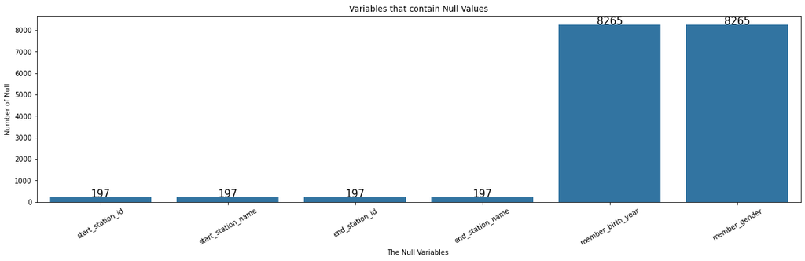

```python
base_color = sb.color_palette()[0]
plt.figure(figsize = [20, 5])
sb.barplot(na_counts.index.values, na_counts, color = base_color )
# get the current tick locations and labels
plt.xticks(rotation=30)
plt.xlabel('The Null Variables ');
plt.title('Variables that contain Null Values');
plt.ylabel('Number of Null');

# Logic to print value on each bar
for i in range (na_counts.shape[0]):
    count = na_counts[i]
    plt.text(i,count+400, count, ha = 'center', va='top', size = 15)
```

## Univariate Exploration

> In this section, investigate distributions of individual variables. Such as User_type, member_gender,duration_sec, starting station and time of the trips.

## User_type & member_gender Visualizations

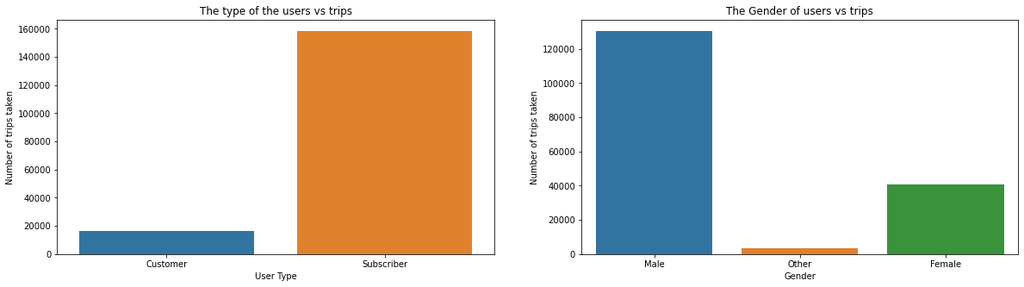

```python
plt.figure(figsize = [20, 5])
plt.subplot(1, 2, 1)
sb.countplot(data=df, x='user_type');
plt.xlabel('User Type');
plt.title('The type of the users vs trips');
plt.ylabel('Number of trips taken');

plt.subplot(1, 2, 2)
sb.countplot(data=df, x='member_gender');
plt.xlabel('Gender');
plt.title('The Gender of users vs trips');
plt.ylabel('Number of trips taken');
```

## Trip duration analysis

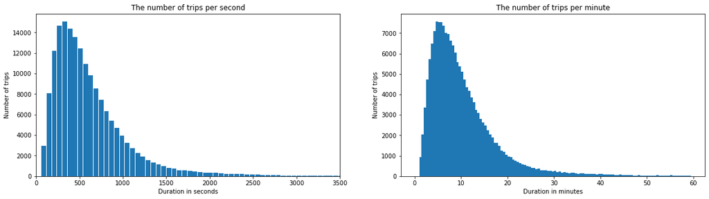

```python
plt.figure(figsize = [20, 5])

plt.subplot(1, 2, 1)
bins = np.arange(0, df['duration_sec'].max()+100,60)
plt.hist(data = df, x = 'duration_sec', bins = bins, rwidth = 0.9)
plt.xlim(0,3500);
plt.xlabel('Duration in seconds');
plt.title('The number of trips per second');
plt.ylabel('Number of trips');

plt.subplot(1, 2, 2)
df['duration_in_min'] = df['duration_sec']/60
bins = np.arange(0, 60,.5)

plt.hist(data = df, x = 'duration_in_min', bins = bins, rwidth = 1)

plt.xlabel('Duration in minutes');
plt.title('The number of trips per minute');
plt.ylabel('Number of trips');
```

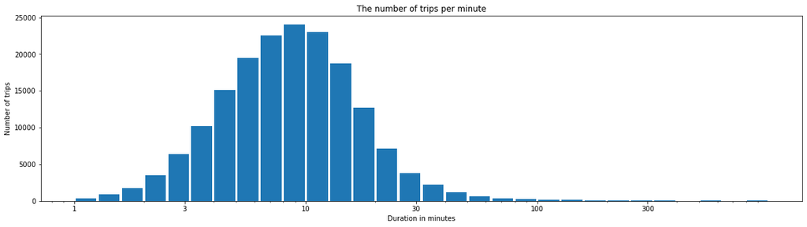

```python
plt.figure(figsize = [20, 5])
bins = 10**np.arange(0 , 3 + 0.1 , 0.1)
ticks =  [ 1 , 3, 10, 30, 100, 300]
labels = ['{}'.format(v) for v in ticks]
plt.hist(data = df , x = 'duration_in_min' , bins = bins, rwidth = 0.9);
plt.xscale('log');
plt.xticks(ticks,labels);
plt.xlabel('Duration in minutes');
plt.title('The number of trips per minute');
plt.ylabel('Number of trips');
```

## Starting Station Analysis.

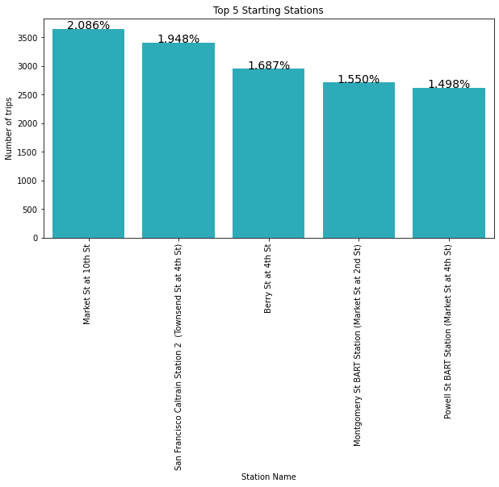

```python
base_color = sb.color_palette()[9]
plt.figure(figsize = [10, 5])
p1 = sb.countplot(x="start_station_name", data=df, order=df.start_station_name.value_counts().iloc[:5].index,
                  color=base_color)
plt.xticks(rotation=45);
plt.xlabel("Station Name")
plt.title("Top 5 Starting Stations")
plt.ylabel('Number of trips');
type_counts = df['start_station_name'].value_counts()
locs, labels = plt.xticks(rotation=90)
# loop through each pair of locations and labels
for loc, label in zip(locs, labels):
    count = type_counts[label.get_text()]
    pct_string = '{:0.3f}%'.format(100*count/len(df))
    plt.text(loc, count+.1, pct_string, ha='center', color = 'black', size = 14)
```

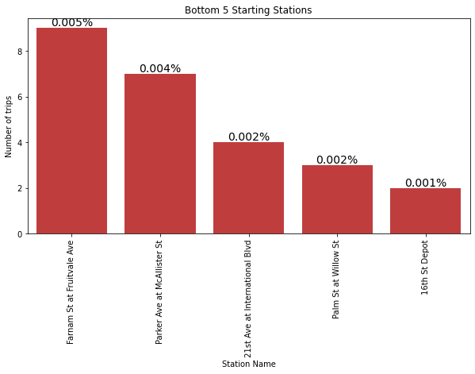

```python
base_color = sb.color_palette()[3]
plt.figure(figsize = [10, 5])
p2 = sb.countplot(x="start_station_name", data=df, order=df.start_station_name.value_counts().iloc[-5:].index,
                  color=base_color)
plt.xticks(rotation=45);
plt.xlabel("Station Name")
plt.title("Bottom 5 Starting Stations")
plt.ylabel('Number of trips');
locs, labels = plt.xticks(rotation=90)
# loop through each pair of locations and labels
for loc, label in zip(locs, labels):
    count = type_counts[label.get_text()]
    pct_string = '{:0.3f}%'.format(100*count/len(df))
    plt.text(loc, count+.1, pct_string, color = 'black',ha='center', size = 14)
```

## Start Time and Day Analysis.

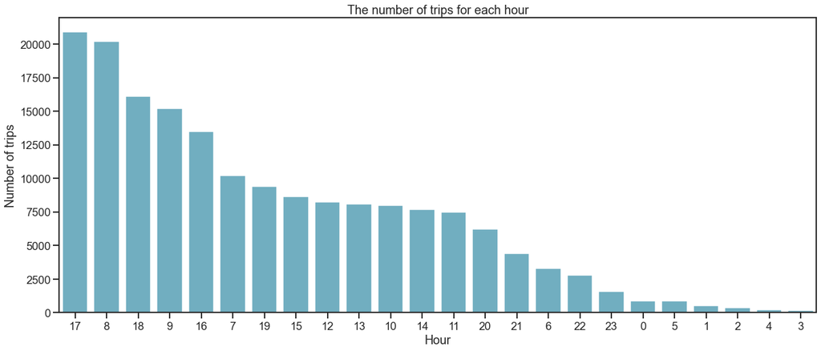

```python
base_color = sb.color_palette()[9]
plt.figure(figsize = [20, 8])
freq = df['hour'].value_counts()

gen_order = freq.index

# Plot the bar chart in the decreasing order of the frequency of the `generation_id`
sb.countplot(data=df, x='hour', color=base_color, order=gen_order);
plt.xlabel("Hour")
plt.title("The number of trips for each hour")
plt.ylabel('Number of trips');
```

> In this section,we will explore variables and their impact on the other variables such as duration on the trips.

## Trip Duration and Trip Hours Analysis.

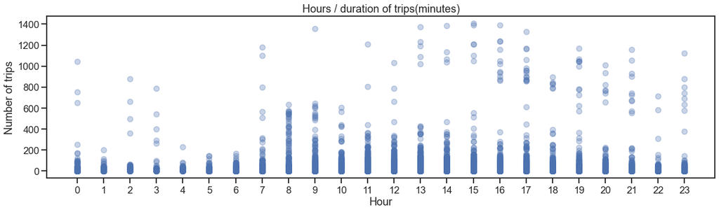

```python
nhours = df['hour'].unique()
plt.figure(figsize = [20, 5])
plt.scatter(data = df, x = 'hour', y = 'duration_in_min', alpha=0.3);
plt.xticks(nhours);
plt.xlabel("Hour")
plt.title("Hours / duration of trips(minutes)")
plt.ylabel('Number of trips');
```

## Day Of The Week Analysis.

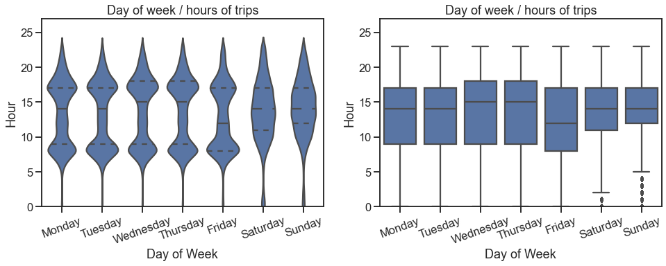

```python
plt.figure(figsize = [16, 5])
base_color = sb.color_palette()[0]
plt.subplot(1, 2, 1)
#Let's return the axes object
ax1 = sb.violinplot(data=df, x='Vday_name', y='hour', color=base_color, inner='quartile')
plt.xticks(rotation=20);
plt.ylim(0,27)
plt.xlabel("Day of Week")
plt.title("Day of week / hours of trips")
plt.ylabel('Hour');

plt.subplot(1, 2, 2)
sb.boxplot(data=df, x='Vday_name', y='hour', color=base_color)
plt.xticks(rotation=20)
plt.ylim(ax1.get_ylim());
plt.xlabel("Day of Week")
plt.title("Day of week / hours of trips")
plt.ylabel('Hour');
```

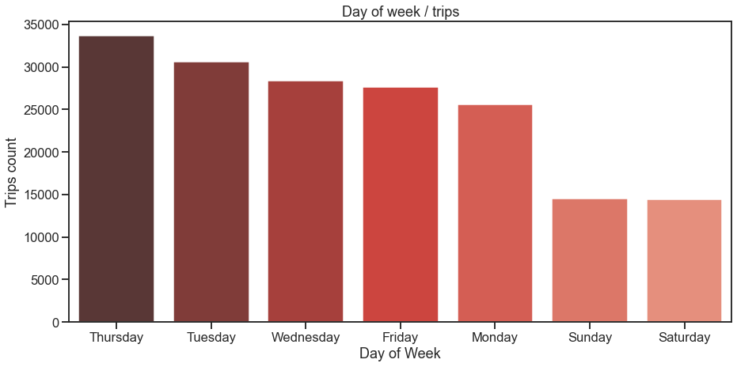

```python
plt.figure(figsize = [15, 7])
total = df['day_name'].value_counts().sum()
day = df['day_name'].value_counts()
y = (day / total)
yy = (day / total).reset_index()
pal = sb.color_palette("Reds_d", len(y))
rank = y.argsort().argsort()
g = sb.barplot(x=df['day_name'].value_counts().index, y=df['day_name'].value_counts(),
               palette=np.array(pal[::-1])[rank] );
plt.xlabel("Day of Week")
plt.title("Day of week / trips")
plt.ylabel('Trips count');
```

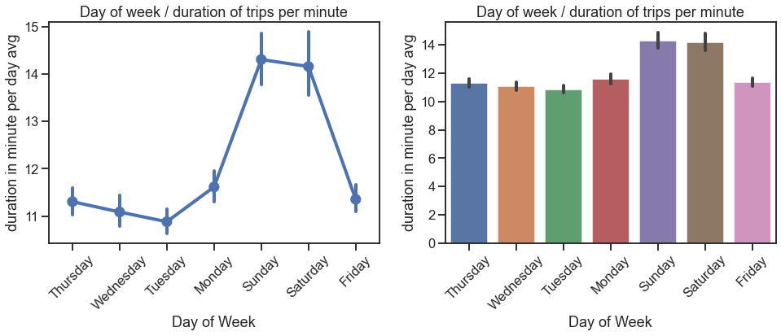

```python
plt.figure(figsize = [16, 5])
base_color = sb.color_palette()[0]

plt.subplot(1, 2, 1)
sb.pointplot(data=df, x='day_name', y='duration_in_min', color=base_color)
plt.xticks(rotation=45);
plt.ylabel('duration in minute per day avg')
plt.xlabel("Day of Week")
plt.title("Day of week / duration of trips per minute");



plt.subplot(1, 2, 2)
sb.barplot(data=df, x='day_name', y='duration_in_min')
plt.xticks(rotation=45);
plt.ylabel('duration in minute per day avg')
plt.xlabel("Day of Week")
plt.title("Day of week / duration of trips per minute");
```

## Multivariate Exploration

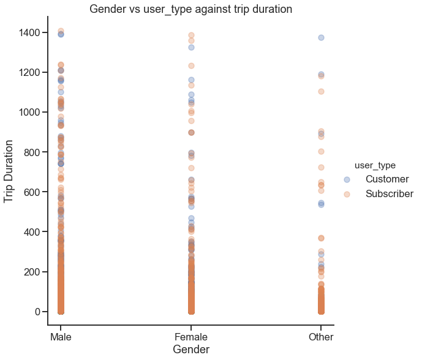

```python
f =sb.FacetGrid(data =  df, hue = 'user_type', height = 8)
f.map(plt.scatter, 'member_gender','duration_in_min', alpha = 0.3)
f.add_legend()
plt.title('Gender vs user_type against trip duration')
plt.xlabel('Gender')
plt.ylabel('Trip Duration');
```

### Let's Explore the Age, Gender, and trip duration

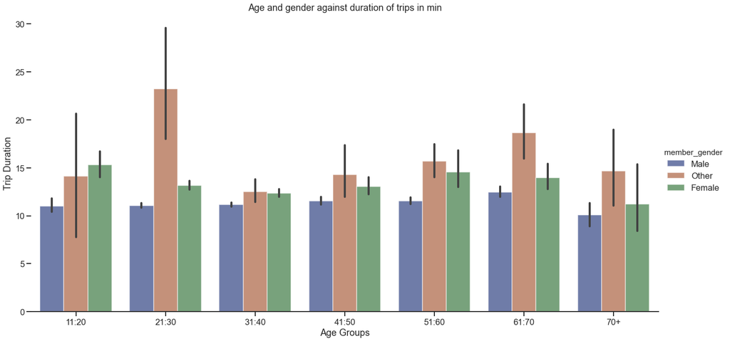

```python
order = df.groupby('age_group').size().index
g = sb.catplot(
    data=df, kind="bar",
    x="age_group", y="duration_in_min", hue="member_gender",palette="dark",
    alpha=.6,height= 9, aspect = 2, order = order  )
g.despine(left=True);
g.set_axis_labels("", "");
plt.title('Age and gender against duration of trips in min')
plt.xlabel('Age Groups')
plt.ylabel('Trip Duration');
```